「上下文的纪律」系列 · 第 5 篇

翻找花掉的token，能节省多少？

▍如果没有发现关键信息，智能体会反复进行翻找

编码智能体执行bug修复任务时有一个稳定的行为模式：如果第一次修改没通过测试，它不会停下，而是把相关文件再整个读一遍。如果还不行，就换个关键词重新搜一遍。如果再不行，就把刚才看过的那段栈轨迹从头再看一遍。华为团队今年发表的这篇论文，从这个循环出发，探索如何节省这类查找工作中的token消耗。

智能体每一轮重读仓库文件，都会往上下文里加东西：大段的文件读取内容、宽泛的搜索结果、几百行的终端输出。执行修复任务需要的信息混在上下文中，但夹杂其中的还有无关函数、重复日志和上一次失败探索的残留信息。华为的论文把重复翻找代码库的代价归纳为两条：一是成本，后续每一步推理都要背负越来越多的token；二是决策质量，关键信息被大量无关内容稀释。关于长上下文研究表明，模型在长输入中并不能可靠地利用所有上下文信息（参考本系列第二篇荐读论文，关于上下文窗口中部信息利用率下降的讨论）。

这篇论文探索了一种和常见思路不同的做法。通常的方法是等prompt已经很长了再压缩，而ContextSniper把处理前移到输出产生的那一刻：读取文件、执行命令的结果先进行一次按意图过滤的检查，只放行与当前任务相关的证据，其余存进窗口外的记忆层，需要时可以取回。

上下文管理是编码智能体的核心功能，目前最常见的方法包括类似Pi这样比较简化通过长度阈值触发、或者Claude Code采用的微压缩+长度触发双重机制。无论哪种方法，核心思路都是在尽量提供完整信息和控制上下文长度之间做取舍。由于上下文管理限于处理成本和效率因素通常只能通过简单逻辑来实现，现有编码智能体的上下文管理仍然是较为粗放的。这篇论文提供一种与常见方法不同的思路，虽然同样也只是一种权衡后的策略，但对于进一步提高上下文管理效率，不失为一种有价值的参考。

本期论文

ContextSniper: AntTrail's Token-Efficient Code Memory for Repository-Level Program Repair  
ContextSniper：AntTrail面向仓库级程序修复的token效率优化代码记忆方法  
Chiwang Luk et al.（华为、香港科技大学广州、南洋理工大学），2026-07（arXiv:2607.01916v3）

简要结论：在编码智能体和代码仓库之间插一层"上下文访问层"。读取文件、执行命令的输出在进入上下文窗口之前先按意图过滤。与任务相关的证据均附带出处信息、原始信息在外部记忆保存并可恢复读入上下文。在SWE-bench Lite同任务对照下，OpenClaw总token可节省51.5%、Claude Code可节省38.9%，修复率各下降2个百分点，修复率损失可接受。

名词速查

▸ SWE-bench Lite：从真实GitHub issue构建的修复任务基准的轻量子集；本文每个对照条件随机抽50个任务。

▸ 宿主智能体（host agent）：负责规划、编辑、验证的编码智能体本体。本文的两个宿主是Claude Code和OpenClaw（核心是Pi），插入层不替换它们。

▸ MCP（Model Context Protocol）：把外部工具接入智能体的标准协议；本文用它向Claude Code提供检索与编辑工具。

▸ 证据包（evidence packet）：过滤后返回给模型的紧凑材料，每条代码摘录附带仓库路径和行区域信息，每条运行时信号标注产生它的命令或编辑指令。

▸ 门控（gate）：在工具输出进入上下文窗口之前决定放行哪些内容的检查环节。

## 一、token开销的大部分在翻找环节，查找结果需要在进入上下文窗口之前进行控制

主流编码智能体通过原生仓库工具获取证据：grep式搜索、整文件读取、bash命令。这些工具的输出不经筛选，直接进入上下文窗口，论文称之为"原始访问"（raw access）。修复任务里最贵的部分往往不是写补丁，而是反复找到那些相关的文件、符号和测试结果。上一篇荐读论文讨论的ACQUIRE是在动手之前把该知道的事备齐，这一篇面对的是另一个环节：每次读文件、每次执行命令，后把哪些结果信息放进上下文窗口。

"When a coding agent cannot find the evidence it needs, it does not stop; it rereads."  
── 中译：编码智能体找不到所需证据时，它不会停下来，而是再读一遍。（原论文§1.1，全文第一句）

单纯删减解决不了这个问题。简单截断可能恰好删掉唯一解释bug的那条测试断言或import依赖。通用摘要会弄糊出处、行号和可编辑性，而这三样恰恰是修复要用的。有效的上下文管理必须删得激进，同时保留住异构的修复信号：issue意图、代码结构、符号定义、失败观察、命令结果、编辑之后的最新状态等关键信息。

论文在相关工作版图上给自己定的位置叫"上下文访问层"（context-access layer）。基准（SWE-bench）定义任务，自主修复智能体（SWE-agent、AutoCodeRover）把上下文选择耦合在自己的探索循环里，流水线式方法（Agentless）则把定位做成一个独立阶段。本文把"哪些仓库与运行时证据允许进入prompt"独立成一层，插在宿主智能体和仓库之间。规划、编辑、验证仍由宿主管理，在新增的一层中只管理证据的路径（AntTrail）。

## 二、ContextSniper的设计：广检索，窄暴露

系统的核心原则是：广检索，窄暴露（retrieve broadly, expose narrowly）。全部仓库证据和运行时输出存在窗口外的记忆层里，用多路信号检索。返回给模型的，只有可能支撑定位、改补丁、做验证的片段和事实。返回的材料论文叫证据包：每段代码摘录带仓库路径和行区域，每条运行时信号标注产生它的命令或编辑指令。方法名字里的Sniper（狙击手）是论文自选的比喻，指从大片噪声中精确截取证据这个动作。

"This paper builds on a different view of context: evidence, not ballast."  
── 中译：本文基于另一种上下文观：上下文是证据，不是压舱物。（原论文§1.2）

通过四个方面来具体实现设计意图：两族记忆、两阶段同步、混合检索、意图感知门控。

| 组件 | 做什么 | 关键细节 |
| --- | --- | --- |
| 双族记忆 | 把代码与运行时证据存到窗口外 | 代码族＋动作族，各分L0摘要／L1元数据／L2全内容三层，AGFS文件系统后端 |
| 两阶段同步 | 编辑之后记忆不失效 | 动作钩子即时刷新＋每轮新提示到达时与工作树对账 |
| 混合检索 | 多信号找证据，按预算确定返回量 | 语义嵌入＋BM25＋符号＋图关系，加权RRF融合；弱召回时ripgrep兜底 |
| 意图感知门控 | 决定什么进入模型视野 | 文件读／命令输出／状态信号三类保留策略；截断处打标记，原件放入外部记忆 |

表 1｜ContextSniper的四件实现组件（原论文§3.2–3.5，作者整理）

记忆层分为两族。代码族存仓库快照：L0是代码摘要，L1是结构化元数据（路径、行区域、符号、签名、图关系），L2是源码切片，Python按顶层类和函数用tree-sitter切分，其他语言退化为重叠行窗。动作族存本次运行的产生物：L0是过滤后的视图，L1是工具名、路径、命令状态，L2是原始未过滤输出。两族都放在AGFS后端上，每个记忆节点是一个目录，保存这三种粒度的文本视图。

由于增加了一层索引，引入了新的问题：直接读原始文件，智能体拿到的永远是磁盘上的当前版本，而通过索引检索，拿到的可能是编辑前的旧信息。旧片段同样带着路径和行号，基于过期代码做的判断会与它先前的编辑冲突。比如重复修改已经改过的地方，或者按已经漂移的行号去定位。针对这个问题，通过“两阶段同步”的机制来解决：第一阶段挂在智能体动作的运行时钩子上：搜索、读文件、编辑、跑命令都会记录触碰路径与修改。通过本层工具进行编辑时还会校验路径、应用替换并触发该文件的记忆刷新。第二阶段在每轮新用户提示到达时，用工作树的改动对索引状态进行核对。通过这样的方式来确保索引信息与实际代码仓库同步。

检索采用混合多路的方式，包含了语义嵌入、BM25词法、ctags符号、图关系（import、调用、包含、相邻文件）四种检索路径。使用加权RRF融合进行结果排序，索引检索太弱时退到ripgrep全文搜索作为兜底。查询意图决定各路的预算：回溯类查询加重路径、符号和搜索词；行为类查询加重语义和图；带状态的调试轮会提升最近触碰过的文件。返回条数随上下文预算自适应调整。

门控按输出类型分别处理。文件读取：保留请求区域、本地定义、导入和邻近代码。测试和shell输出：保留命令行、退出状态、断言消息、栈轨迹、失败路径和简洁的成功信号。其余输出：保留状态信号，即变更文件、触碰符号、仓库状态。长的样板代码、重复日志、无关文件区域、无信息量的尾部，从进入模型视野的版本中删去。门控遵循保守原则：删掉有用证据的代价可能大于多花token，所以宁可少删。凡是被截短的输出，原文存进动作记忆的L2层，返回视图上带一个截断标记和一行恢复提示，模型发现信息不够时可以要求展开原文。

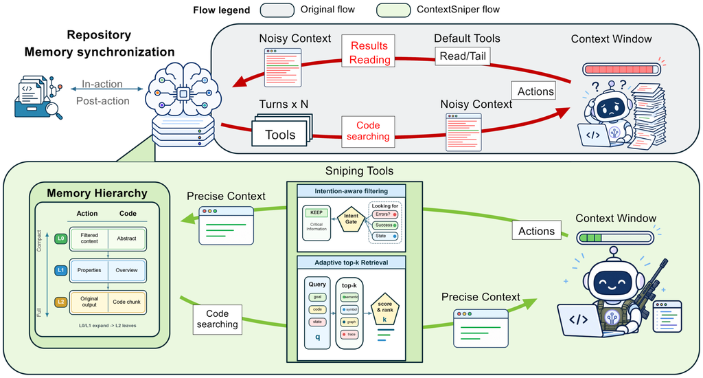

图 2｜ContextSniper架构：上为基线路径，宽泛搜索与长输出直接累积进上下文；下为插入层路径，证据先进AGFS记忆层级，经混合检索与意图感知门控后返回紧凑证据包（原论文Figure 2）

## 三、效果：token节省四到五成，bug修复率基本不变

实验在SWE-bench Lite上进行。每个宿主智能体随机抽50个任务，基线（原生工具）与插入层执行同样的任务进行对照。两个宿主分别采用两种部署方式：OpenClaw是开源智能体，插入层走plugin和运行时钩子接入；Claude Code是生产环境工作流，走MCP协议接入。模型为Claude Haiku 4.5。

| 宿主智能体 | 方法 | 单任务平均token | 总成本 | 平均动作数 | 修复（50任务） |
| --- | --- | --- | --- | --- | --- |
| OpenClaw | 基线 | 1.36M | $0.635 | 32.1 | 13个（26.0%） |
| OpenClaw | 插入ContextSniper | 0.66M（−51.5%） | $0.404（−36.4%） | 17.2（−46.4%） | 12个（24.0%） |
| Claude Code | 基线 | 1.45M | $15.09 | 29.9 | 16个（32.0%） |
| Claude Code | 插入ContextSniper | 0.79M（−38.9%） | $10.97（−27.3%） | 19.2（−35.7%） | 15个（30.0%） |

表 2｜主结果（原论文Table 2，SWE-bench Lite每宿主50个匹配任务，作者整理）

OpenClaw上，单任务平均token从1.36M降到0.66M，总降幅51.5%；成本降低36.4%；动作数从32.1降到17.2，降低46.4%，其中读文件和搜索类的上下文获取动作从572降到461。Claude Code上，总token从85.97M降到52.55M，降低38.9%，成本降低27.3%，动作数降低35.7%。动作数同步下降说明过滤改变了行为：模型收到的每次输出更紧凑，重复翻找随之减少。

修复率的结果体现出这一方法主要是提高效率，而不是提升解决率。两个宿主上修复数各下降1个案例（26.0%到24.0%、32.0%到30.0%）。由于SWE-bench对修复完成的验证本身存在验证任务执行失败造成无法有效判定的情况，且这类故障在两组之间次数不均，因此1个案例的差异不足以形成有效结论。可以大致认为增加这层上下文过滤机制大幅节省了成本，没有修复率提升效果，但也没有可测的修复率损失。

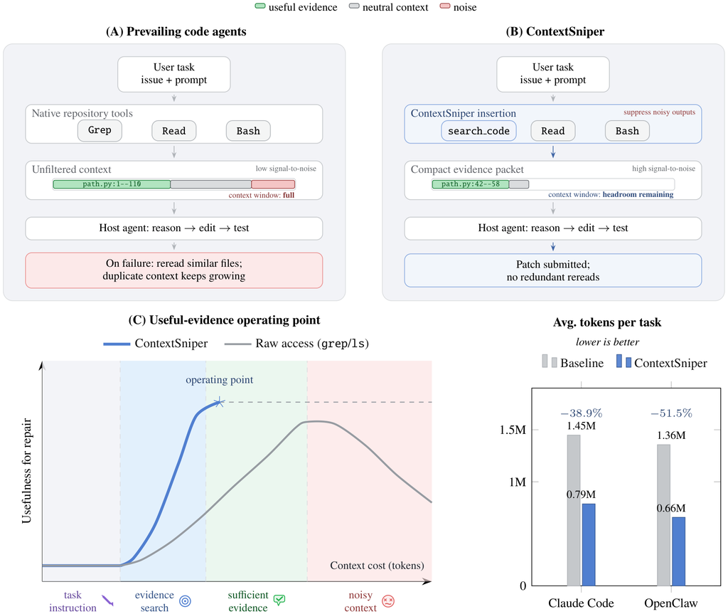

图 1｜基线（A）与插入层（B）的工作流对照，(C)为概念示意：证据够用之后再增加上下文，多半是不必要成本和干扰；条形为两宿主单任务平均token实测（原论文Figure 1）

## 四、50个任务里有5个反而更贵：门控的适用条件

平均值之外，数据分布更有信息量。图3把每个任务的基线token与插入层token画成散点，OpenClaw的50个匹配任务里45个落在对角线下方（更省），Claude Code的任务同样大多在下方。剩下5个上涨的案例，论文逐个核查了执行轨迹，归纳为两类情况。

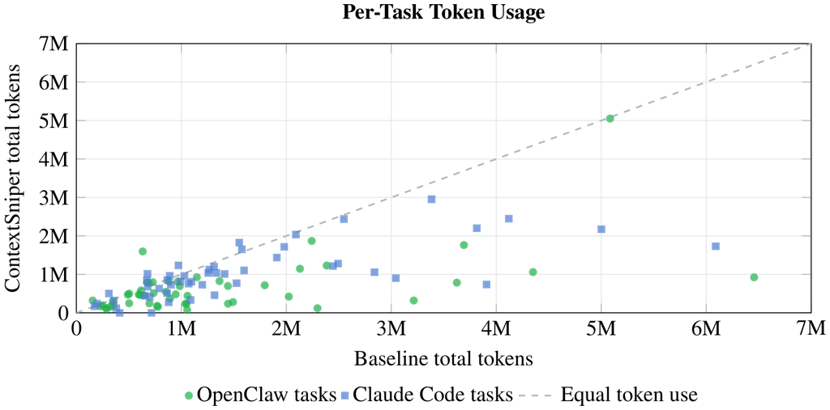

图 3｜逐任务token对照：每个点是一个任务，对角线下方表示插入层更省（原论文Figure 7）

一类是固定开销摊不完。pylint-7228、flask-5063、matplotlib-24265三个任务上，插入层的动作数与基线相同，只是多出2到4次代码检索调用，token涨幅9.6%到17.3%。任务本身很短的情况下，检索层的启动和搜索轮次省不回来。另一类是检索没给出决定性的证据。seaborn-3407上涨152.3%：插入层路径用了6次检索、32个动作，基线只用21个动作就完成了。当首个证据包没命中关键文件时，宿主只能接着搜。配套的召回测量（按仓库统计目标文件是否出现在检索前几名）显示，召回低的仓库正是成本上涨集中的地方。

## 五、与压缩路线的区别：删得不均匀，保留出处，原件可恢复

在上下文管理上有三个常见的方面：prompt压缩（LLMLingua、RECOMP、Selective Context等）作用于已经选进prompt的文本，把长度缩短。工具输出过滤（RTK报告省60–90%，Headroom省60–95%）在命令和工具输出上做过滤，与本文的尝试最接近，但通常没有与工作树同步的代码记忆。仓库记忆与定位（RepoGraph、KGCompass等）提供检索，但不控制哪些内容进入窗口。ContextSniper把三件事合成一个访问层，在比通常压缩更靠前的环节上发挥作用。

| 维度 | prompt压缩 | 工具输出过滤 | ContextSniper门控 |
| --- | --- | --- | --- |
| 作用位置 | 已选进prompt的文本 | 命令与工具输出 | 读与命令输出进窗口之前，含检索返回 |
| 出处保留 | 摘要后常模糊 | 各方法不一 | 路径＋行区域＋产生命令 |
| 原件可恢复 | 一般不留原件 | Headroom可取回 | 原件入动作记忆，带恢复提示 |
| 代码记忆同步 | 无 | 无 | 编辑后两阶段同步 |

表 3｜压缩与门控两条上下文控制路线的对比（原论文§2.4–2.5、§3.5，作者整理）

门控机制与均匀压缩最实质的差异在于可追溯与可恢复。压缩后的文本是一段新的话，出处和行号可能已经模糊；门控返回的每条证据均带有出处，被删的原件仍保留在二级记忆里可以按需恢复。这样，模型拿到的不是一份独立的摘要，而是一份带索引的节选。

部署上，因为边界收窄到只控制证据筛选路径、不影响宿主的规划编辑验证，同一套机制有两种接入方法：Claude Code采用MCP工具，search_code作为grep和探索性读取的首选替代，配对的edit_file负责校验路径、应用替换并刷新记忆。OpenClaw采用plugin和运行时钩子。论文的讨论部分把这层机制的部署位置总结为：宿主智能体决定解决什么问题、写什么补丁；插入层决定在有限上下文预算下怎么暴露仓库证据。上下文管理由此成为系统里的一个显式层，而不是文件读取和shell命令顺带的附属功能。

▍注记：这篇论文的边界

每宿主50任务的实验规模较小，仅能作为试点。论文自列的待办包括更标准的验证、更多任务、SWE-bench Verified与置信区间。修复率差异受验证错误不均衡影响，实验结果只能证明有效率提升而对质量的影响不明确。效果依赖检索与索引质量：证据信号弱、分布在不寻常文件里、或只有跑完测试才可见时，检索可能发生漏检。过滤策略太激进则可能会删掉有用证据，论文把可学习的过滤策略与可人工检查的取舍轨迹列为未来工作。基准为单一Python仓库集合，未做跨语言验证。仅5个任务的Django试点是探索性证据，规模太小无法形成有效结论。

▍上下文控制关口前移，在实际工作流的应用

这篇论文的论证链条：翻找关键信息占了token开销的主要部分。把过滤位置前移到输出产生之时，配合窗口外记忆与保守放行，在两个主流编码Agent上实现了bug修复任务节省四到五成token而修复率基本不变。根据对具体任务的分析发现，这一方法在检索有效性较高时收益较大，检索失败率高时反而增加开销。论文尝试的方法尚未成为主流编码智能体的内置功能，如果要在实际的工作流中应用，有以下值得参考的做法：

1. 在上下文进入窗口之前设置过滤环节，所有信息以摘要方式提供并且保留出处链接：所有提供的上下文证据附带路径、行号和产生信息的命令，被删的原件留底可恢复，是提升上下文质量的有效方法。简单的均匀摘要方法会造成信息丢失和模糊，效果往往难以保证。

2. 在当前模型普遍上下文窗口较宽裕的情况下，上下文筛选方面首选保守优先策略：删错证据的代价大于多花token。在截断的地方留标记和恢复途径，保留模型按需渐进加载的入口，是明智的做法。

以上两项方法既可以参考论文的做法使用MCP或者Hook来实现，实际上在文档和代码注释规范中做好索引锚点，主动为仓库建立索引文件，也可以在一定程度上为编码Agent更好的自主管理上下文提供便利。论文的研究提供了一个很有价值的启示：上下文信息的质量在于“精准而具体的提供有帮助的信息”，精准和具体两个要素缺一不可。因此，早期只看窗口占用大小，占用比例高了就compact的使用方法实际并不科学。有些编码工具也会建议用户每个任务，或者每个阶段通过新开会话的方式来清理上下文。这也是因为简单依靠只摘要压缩，丢失的信息过多，被压缩后的信息已经没有多少实际的应用价值了。我们仍然秉持AI应用中“Context is all you need”的观点。在讨论了上下文窗口的特点，如何做信息检索和进入大模型窗口前的筛选后，下一篇我们将讨论如何对任务过程中的长上下文进行高效的处理。

论文：ContextSniper（arXiv:2607.01916v3，2026-07，Chiwang Luk et al.，华为/HKUST(GZ)/NTU）。评估代码与AntTrail引擎见gitcode.com/lukchiwang/ContextSniper及gitcode.com/datagallery/AntTrail。文中图表均引自原论文（Figure 1/2/7）；表1–3依据原论文§3.2–3.5、Table 2、§2.4–2.5及§4.3由作者整理，非原图截取；引文为原文直录并附中译；数字已逐项与论文PDF原文核对。